# Logistic regression

## 1. Reading the data

Here we use modified student alcohol consumption data described [here](https://archive.ics.uci.edu/ml/datasets/STUDENT+ALCOHOL+CONSUMPTION).

The joined data set used in the analysis exercise combines the two student alcohol consumption data sets. The following adjustments have been made:

- The variables not used for joining the two data have been combined by averaging (including the grade variables)
- ‘alc_use’ is the average of ‘Dalc’ and ‘Walc’
- ‘high_use’ is TRUE if ‘alc_use’ is higher than 2 and FALSE otherwise

The R code about wrangling described above is given [here](https://github.com/noykova/IODS-project/blob/master/Data/create_alc.R)

The data are read using the following command:

```r
alc<- read.table("alc.txt", header=TRUE)
dim(alc)
```

```
## [1] 382  35
```

```r
str(alc)
```

```
## 'data.frame':    382 obs. of  35 variables:
##  $ school    : Factor w/ 2 levels "GP","MS": 1 1 1 1 1 1 1 1 1 1 ...
##  $ sex       : Factor w/ 2 levels "F","M": 1 1 1 1 1 2 2 1 2 2 ...
##  $ age       : int  18 17 15 15 16 16 16 17 15 15 ...
##  $ address   : Factor w/ 2 levels "R","U": 2 2 2 2 2 2 2 2 2 2 ...
##  $ famsize   : Factor w/ 2 levels "GT3","LE3": 1 1 2 1 1 2 2 1 2 1 ...
##  $ Pstatus   : Factor w/ 2 levels "A","T": 1 2 2 2 2 2 2 1 1 2 ...
##  $ Medu      : int  4 1 1 4 3 4 2 4 3 3 ...
##  $ Fedu      : int  4 1 1 2 3 3 2 4 2 4 ...
##  $ Mjob      : Factor w/ 5 levels "at_home","health",..: 1 1 1 2 3 4 3 3 4 3 ...
##  $ Fjob      : Factor w/ 5 levels "at_home","health",..: 5 3 3 4 3 3 3 5 3 3 ...
##  $ reason    : Factor w/ 4 levels "course","home",..: 1 1 3 2 2 4 2 2 2 2 ...
##  $ nursery   : Factor w/ 2 levels "no","yes": 2 1 2 2 2 2 2 2 2 2 ...
##  $ internet  : Factor w/ 2 levels "no","yes": 1 2 2 2 1 2 2 1 2 2 ...
##  $ guardian  : Factor w/ 3 levels "father","mother",..: 2 1 2 2 1 2 2 2 2 2 ...
```

[output cut: 21 more lines]

```r
head(alc)
```

```
##   school sex age address famsize Pstatus Medu Fedu     Mjob     Fjob
## 1     GP   F  18       U     GT3       A    4    4  at_home  teacher
## 2     GP   F  17       U     GT3       T    1    1  at_home    other
## 3     GP   F  15       U     LE3       T    1    1  at_home    other
## 4     GP   F  15       U     GT3       T    4    2   health services
## 5     GP   F  16       U     GT3       T    3    3    other    other
## 6     GP   M  16       U     LE3       T    4    3 services    other
##       reason nursery internet guardian traveltime studytime failures
## 1     course     yes       no   mother          2         2        0
## 2     course      no      yes   father          1         2        0
## 3      other     yes      yes   mother          1         2        2
## 4       home     yes      yes   mother          1         3        0
## 5       home     yes       no   father          1         2        0
## 6 reputation     yes      yes   mother          1         2        0
##   schoolsup famsup paid activities higher romantic famrel freetime goout
## 1       yes     no   no         no    yes       no      4        3     4
## 2        no    yes   no         no    yes       no      5        3     3
## 3       yes     no  yes         no    yes       no      4        3     2
## 4        no    yes  yes        yes    yes      yes      3        2     2
## 5        no    yes  yes         no    yes       no      4        3     2
## 6        no    yes  yes        yes    yes       no      5        4     2
##   Dalc Walc health absences G1 G2 G3 alc_use high_use
## 1    1    1      3        5  2  8  8     1.0    FALSE
## 2    1    1      3        3  7  8  8     1.0    FALSE
## 3    2    3      3        8 10 10 11     2.5     TRUE
## 4    1    1      5        1 14 14 14     1.0    FALSE
## 5    1    2      5        2  8 12 12     1.5    FALSE
## 6    1    2      5        8 14 14 14     1.5    FALSE
```

```r
colnames(alc)
```

```
##  [1] "school"     "sex"        "age"        "address"    "famsize"
##  [6] "Pstatus"    "Medu"       "Fedu"       "Mjob"       "Fjob"
## [11] "reason"     "nursery"    "internet"   "guardian"   "traveltime"
## [16] "studytime"  "failures"   "schoolsup"  "famsup"     "paid"
## [21] "activities" "higher"     "romantic"   "famrel"     "freetime"
## [26] "goout"      "Dalc"       "Walc"       "health"     "absences"
## [31] "G1"         "G2"         "G3"         "alc_use"    "high_use"
```

## 2. Choice of depending variables, which affect alcohol consumption

The purpose of this analysis is to study the relationships between **high/low alcohol consumption** and some of the other variables in the data.

From phisiology is known that the alcohol has different influence on male and females. Therefore we assume **sex** as important dependent variable to be investigated further.

If the student has a problem with the alcohol, he or she surely will tend to skip the school classes more often. So, the secont dependent variable we choose to be **absence**.

Alcohol consumption surely will influence the sdudent grades, which quantify the success of study process. Thus we chose the **grades** as third dependent variable.

At this stage we find logical to assume that the alcohol consumption is influenced by the **freetime**. If the students have more free time,they will have more possibilities to go to the parties or to have other activities with alcohol consumption.

## 3. Cross-tabulations, bar plots and box plots for investigating the relationships between alcohol consumptions and the chosen dependent variables.

### Box plots

The box plot (box, whisker diagram) is a standardized way of displaying the distribution of data based on the five number summary: minimum, first quartile, median, third quartile, and maximum. In the simplest box plot the central rectangle spans the first quartile to the third quartile (the interquartile range or IQR). A segment inside the rectangle shows the median and “whiskers” above and below the box show the locations of the minimum and maximum. Values outside the whiskers can be considered as outliers, unusually distant observations.

Here we use box-plot analyses, provided in DataCamp exercise, and add two additional plots aiming to clarify the influence on free time on alcohol consumptions, grades and absences.

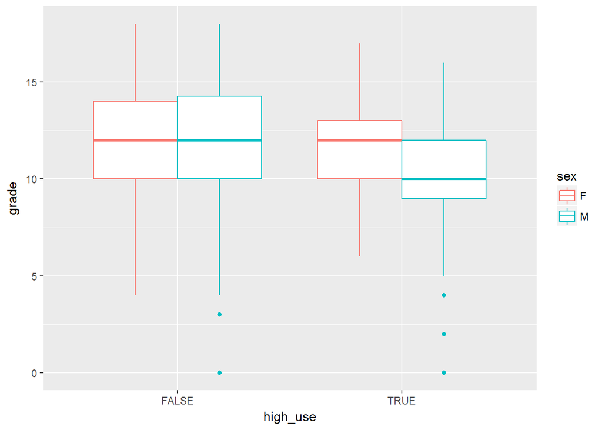

```r
library(GGally)
library(ggplot2)
g1 <- ggplot(alc, aes(x = high_use, y = G3, col=sex))
g1 + geom_boxplot() + ylab("grade")
```

We see that the distributions of grades for male and female students who have high consumption of alcohol,have different medians and deviations.

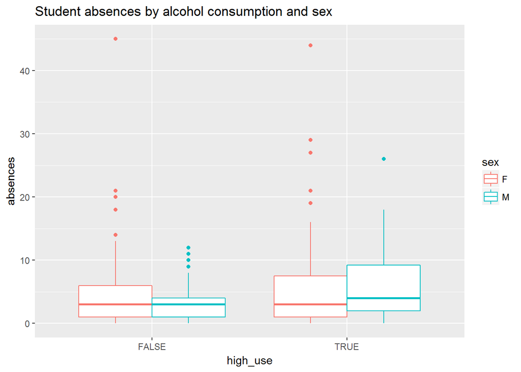

```r
g2 <- ggplot(alc, aes(x = high_use, y = absences, col=sex)) + ggtitle("Student absences by alcohol consumption and sex")

g2 + geom_boxplot() + ylab("absences")
```

This plot shows that the distributions of absences for male and female students who have high consumption of alcohol, have different medians and deviations.

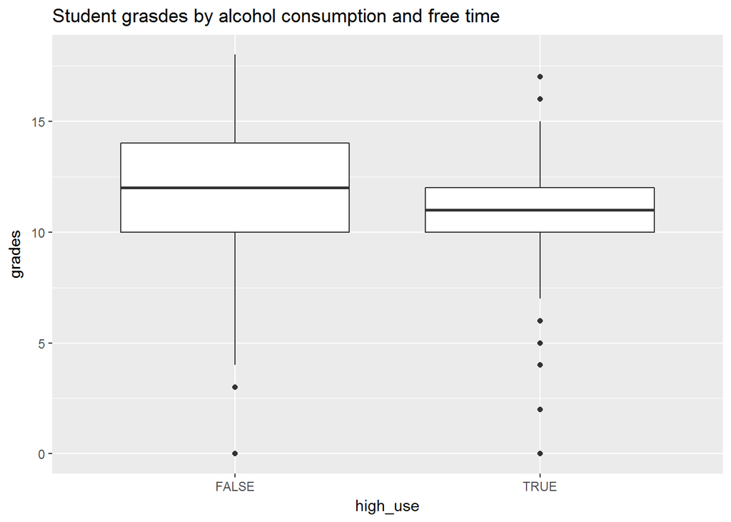

```r
g3 <- ggplot(alc, aes(x = high_use, y = G3, col=freetime)) + ggtitle("Student grasdes by alcohol consumption and free time")

g3 + geom_boxplot() + ylab("grades")
```

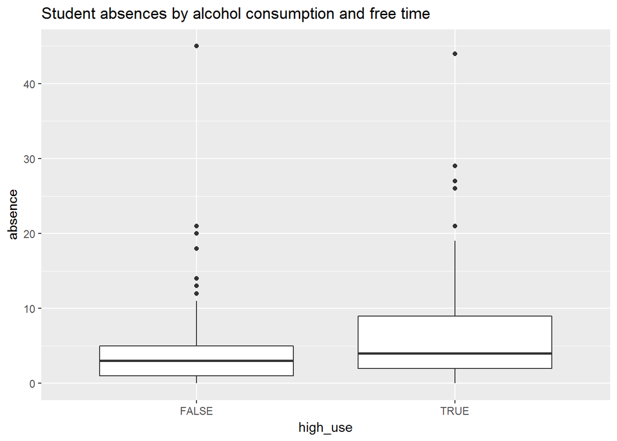

```r
g4 <- ggplot(alc, aes(x = high_use, y = absences, col=freetime)) + ggtitle("Student absences by alcohol consumption and free time")


g4 + geom_boxplot() + ylab("absence")
```

From these plots becomse clear that it is logical to assume sex, absence, grade and free time as variables, which could be assumed to have high impact on alcohol consumption.

### Bar plots

Here the output varable high_use is binary and theefore we should explore another techniques.

Bar plots are one of the most commonly used kind of data visualization. They are used to display numeric values (on the y-axis), for different categories (on the x-axis).

Bar plots need not be based on counts or frequencies. We can create bar plots that represent means, medians, standard deviation. Then we have tuo use the aggregate( ) function and pass the results to the barplot( ) function.

Here we have examined the counts of different variables on y-axes. The grouped plots below present the counts of four dependent variables. The alcohol consumption is given as fill:

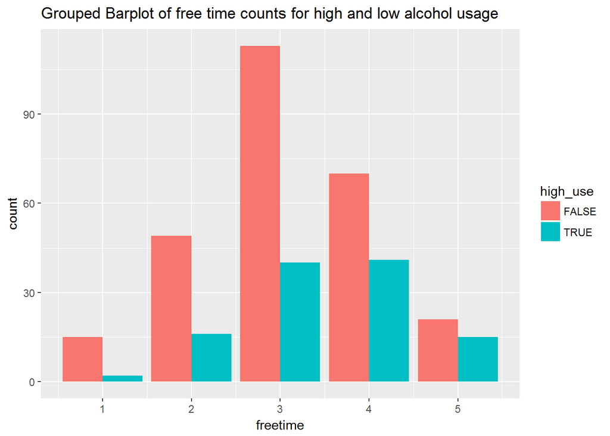

```r
bp <- ggplot(alc, aes(freetime, fill=high_use)) + geom_bar(position="dodge") +
  ggtitle("Grouped Barplot of free time counts for high and low alcohol usage")
bp
```

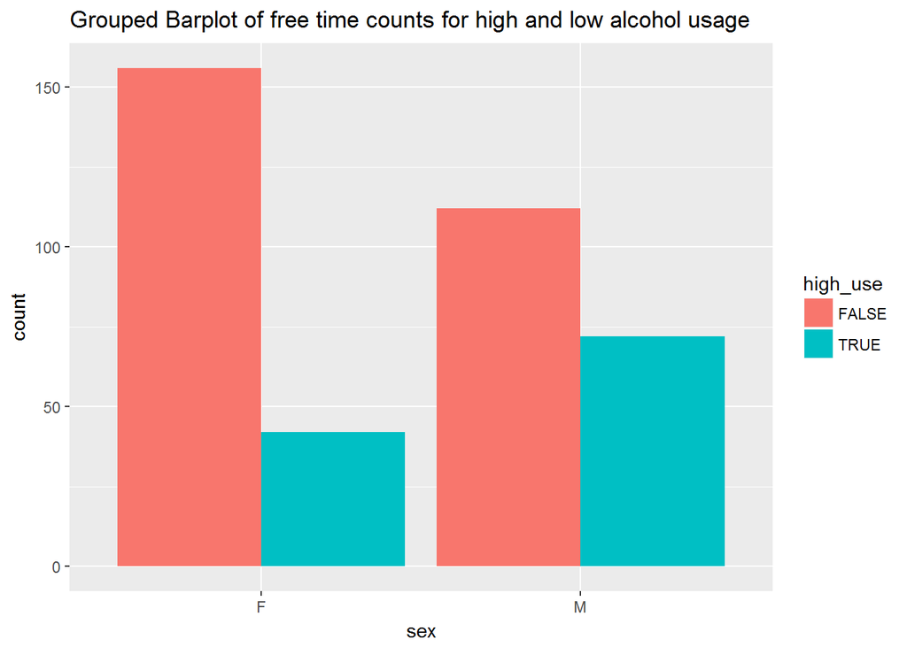

```r
bp2 <- ggplot(alc, aes(sex, fill=high_use)) + geom_bar(position="dodge") +
  ggtitle("Grouped Barplot of free time counts for high and low alcohol usage")
bp2
```

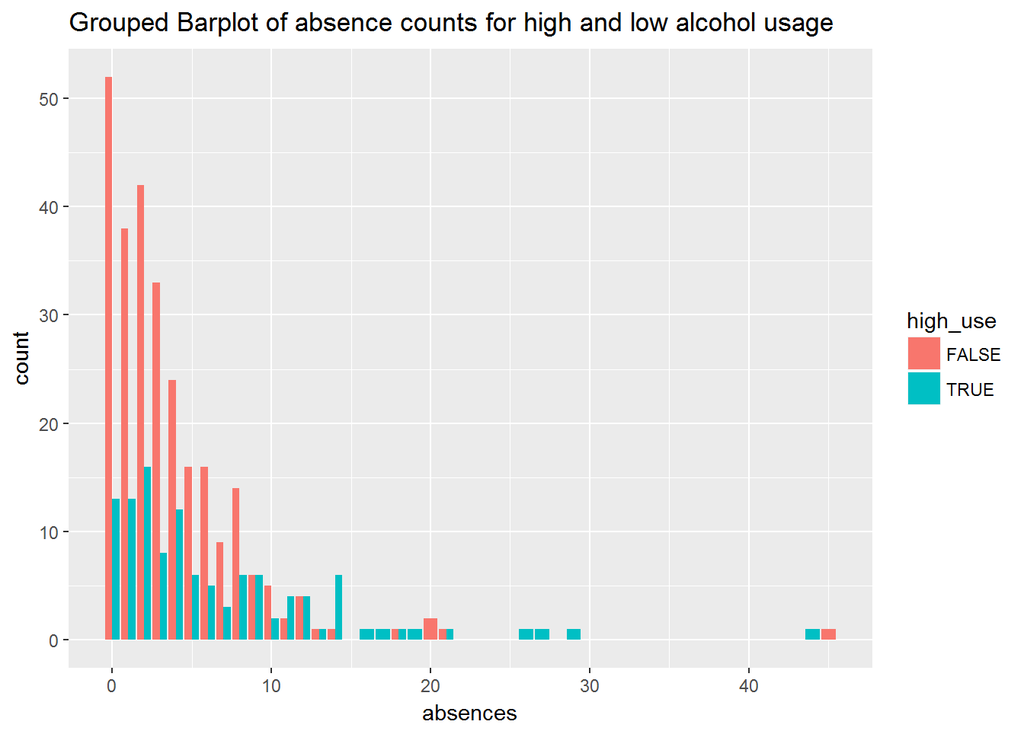

```r
bp3 <- ggplot(alc, aes(absences, fill=high_use)) + geom_bar(position="dodge") +
  ggtitle("Grouped Barplot of absence counts for high and low alcohol usage")
bp3
```

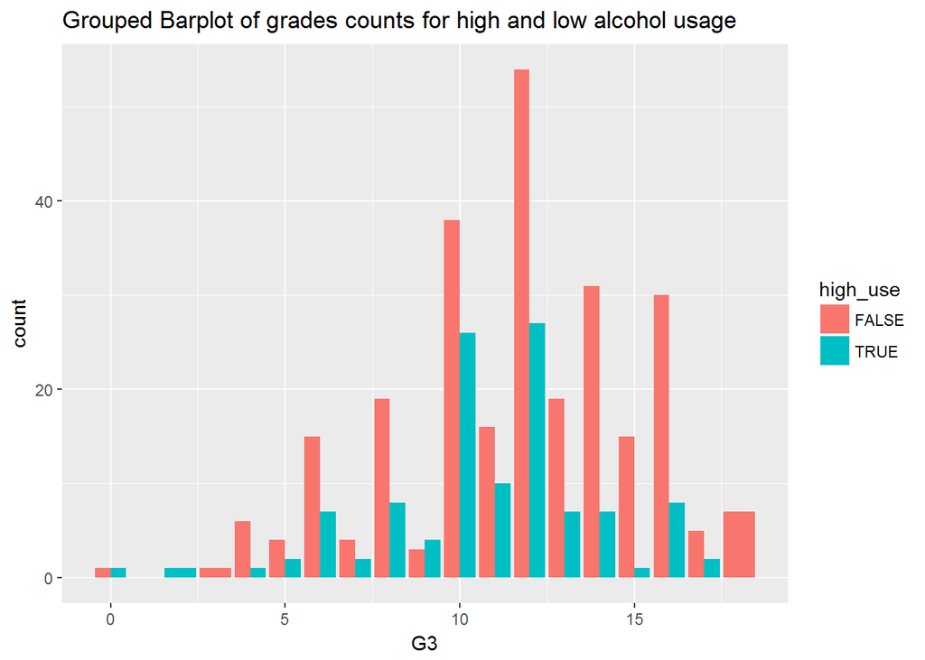

```r
bp4 <- ggplot(alc, aes(G3, fill=high_use)) + geom_bar(position="dodge") +
  ggtitle("Grouped Barplot of grades counts for high and low alcohol usage")
bp4
```

The bar graph of free time counts show that the use of alcohol is higer for gigher values of free time values. Az expected for higher number of absences the use of alcohol is higher.

Next bar plot shows the sependence of grades on high use of alcohol and free time. It is clear that students who have more free time tends to use alcohol and get lower grades.

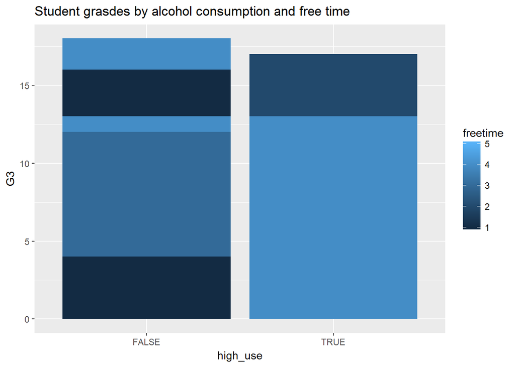

```r
b2 <- ggplot(alc, aes(x=high_use, y=G3, fill=freetime)) +
  geom_bar(stat="identity", position=position_dodge()) +
  ggtitle("Student grasdes by alcohol consumption and free time")
b2
```

Similar graph is drawn for the abcebses. Here is more clear that the students, who use alcohol have both more free time and bigger number of ancenses.

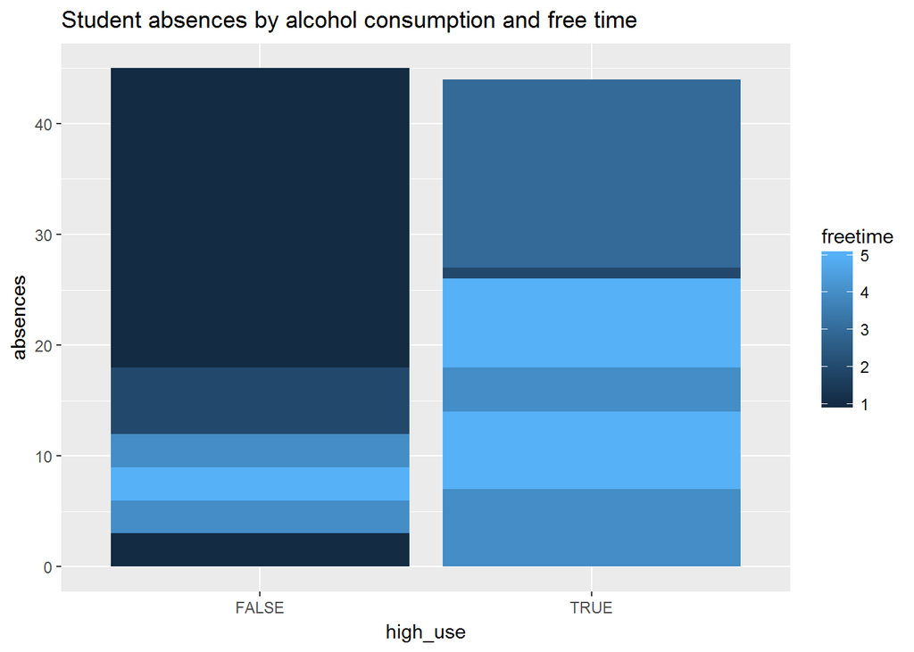

```r
#dependence of absences on high_use and sex.
b3 <- ggplot(alc, aes(x=high_use, y=absences, fill=freetime)) +
  geom_bar(stat="identity", position=position_dodge()) +
  ggtitle("Student absences by alcohol consumption and free time")
# draw the plot
b3
```

### Cross-tabulations (contingency table)

Cross tabulations are type of tables in a matrix format that displays the (multivariate) frequency distribution of the variables. They provide a basic picture of the interrelation between two variables and can help find interactions between them.

In CrossTable() function we can control whether row percentages (prop.r), column percentages (prop.c), or table percentages (prop.t) show up by making them TRUE in the call to CrossTable. Chi - square distribution is also shown.

We construct cross tables for all dependent variables.

```r
library(descr)
CrossTable(alc$freetime,alc$high_use, prop.t=TRUE, prop.r=TRUE, prop.c=TRUE)
```

```
##    Cell Contents
## |-------------------------|
## |                       N |
## | Chi-square contribution |
## |           N / Row Total |
## |           N / Col Total |
## |         N / Table Total |
## |-------------------------|
##
## =====================================
##                 alc$high_use
## alc$freetime    FALSE    TRUE   Total
## -------------------------------------
## 1                  15       2      17
##                 0.792   1.862
##                 0.882   0.118   0.045
##                 0.056   0.018
##                 0.039   0.005
## -------------------------------------
## 2                  49      16      65
##                 0.253   0.595
##                 0.754   0.246   0.170
##                 0.183   0.140
##                 0.128   0.042
## -------------------------------------
## 3                 113      40     153
##                 0.298   0.702
##                 0.739   0.261   0.401
##                 0.422   0.351
##                 0.296   0.105
## -------------------------------------
## 4                  70      41     111
##                 0.796   1.872
##                 0.631   0.369   0.291
##                 0.261   0.360
##                 0.183   0.107
## -------------------------------------
## 5                  21      15      36
##                 0.717   1.686
##                 0.583   0.417   0.094
##                 0.078   0.132
##                 0.055   0.039
## -------------------------------------
## Total             268     114     382
##                 0.702   0.298
## =====================================
```

We again see the dependence between bigger ammount of free time and high consumption of alcohol.

```r
CrossTable(alc$sex,alc$high_use, prop.t=TRUE, prop.r=TRUE, prop.c=TRUE)
```

```
##    Cell Contents
## |-------------------------|
## |                       N |
## | Chi-square contribution |
## |           N / Row Total |
## |           N / Col Total |
## |         N / Table Total |
## |-------------------------|
##
## ================================
##            alc$high_use
## alc$sex    FALSE    TRUE   Total
## --------------------------------
## F            156      42     198
##            2.102   4.942
##            0.788   0.212   0.518
##            0.582   0.368
##            0.408   0.110
## --------------------------------
## M            112      72     184
##            2.262   5.318
##            0.609   0.391   0.482
##            0.418   0.632
##            0.293   0.188
## --------------------------------
## Total        268     114     382
##            0.702   0.298
## ================================
```

## 3. Logistic regression

Next we model the output variable high_use as a function of chosen dependent variables using logistic regression.

Logistic regression is a method for fitting a regression curve, y = f(x), when y consists of proportions or probabilities, or binary coded (0,1–failure, success) data. When the response is a binary (dichotomous) variable, and x is numeric, logistic regression fits a logistic curve to the relationship between x and y.

We define the students free time as a factorial variable (it takes values 1-5). The model and results (summary and coefficients) are given using following functions:

```r
alc$freetime <- factor(alc$freetime)
m <- glm(high_use ~ G3 + absences+sex+freetime, data = alc, family = "binomial")

summary(m)
```

```
##
## Call:
## glm(formula = high_use ~ G3 + absences + sex + freetime, family = "binomial",
##     data = alc)
##
## Deviance Residuals:
##     Min       1Q   Median       3Q      Max
## -1.6795  -0.8329  -0.6122   1.0647   2.1349
##
## Coefficients:
##             Estimate Std. Error z value Pr(>|z|)
## (Intercept) -2.45690    1.00686  -2.440  0.01468 *
## G3          -0.07553    0.03653  -2.068  0.03866 *
## absences     0.09651    0.02276   4.240 2.24e-05 ***
## sexM         0.88658    0.24847   3.568  0.00036 ***
## freetime2    1.30818    0.94479   1.385  0.16616
## freetime3    1.41907    0.91790   1.546  0.12210
## freetime4    1.81731    0.92203   1.971  0.04873 *
## freetime5    1.78978    0.96758   1.850  0.06435 .
## ---
## Signif. codes:  0 '***' 0.001 '**' 0.01 '*' 0.05 '.' 0.1 ' ' 1
##
## (Dispersion parameter for binomial family taken to be 1)
##
##     Null deviance: 465.68  on 381  degrees of freedom
## Residual deviance: 418.34  on 374  degrees of freedom
## AIC: 434.34
##
## Number of Fisher Scoring iterations: 5
```

```r
coef(m)
```

```
## (Intercept)          G3    absences        sexM   freetime2   freetime3
## -2.45689613 -0.07553214  0.09650664  0.88657847  1.30818455  1.41906976
##   freetime4   freetime5
##  1.81730551  1.78977515
```

The logistic regression coefficients give the change in the log odds of the outcome for a one unit increase in the predictor variable.

We can use the confint function to obtain confidence intervals for the coefficient estimates. For logistic models, confidence intervals are based on the profiled log-likelihood function. We can also get confidence intervals based on just the standard errors by using the default method.

```r
confint(m)
```

```
##                   2.5 %       97.5 %
## (Intercept) -4.78973005 -0.713705961
## G3          -0.14778245 -0.004113323
## absences     0.05366041  0.143382613
## sexM         0.40452432  1.380580560
## freetime2   -0.32049218  3.515322927
## freetime3   -0.13114527  3.597014983
## freetime4    0.25536845  4.000588764
## freetime5    0.10649632  4.032065978
```

Confidence intervals using standard errors:

```r
confint.default(m)
```

```
##                   2.5 %       97.5 %
## (Intercept) -4.43031196 -0.483480302
## G3          -0.14712585 -0.003938437
## absences     0.05189363  0.141119657
## sexM         0.39958049  1.373576441
## freetime2   -0.54356698  3.159936066
## freetime3   -0.37997251  3.218112035
## freetime4    0.01016471  3.624446311
## freetime5   -0.10664973  3.686200033
```

These tables show that confidence intervals for all estimated parameters are acceptable.

```r
library(aod)
wald.test(b = coef(m), Sigma = vcov(m), Terms = 4:7)
```

```
## Wald test:
## ----------
##
## Chi-squared test:
## X2 = 19.8, df = 4, P(> X2) = 0.00056
```

We can also exponentiate the coefficients and interpret them as odds-ratios. To get the exponentiated coefficients, we tell R that we want to exponentiate (exp), and that the object we want to exponentiate is called coefficients and it is part of model m (coef(m)). We use the same logic to get odds ratios and their confidence intervals, by exponentiating the confidence intervals from before. To put it all in one table, we use cbind to bind the coefficients and confidence intervals column-wise.

```r
exp(coef(m))
```

```
## (Intercept)          G3    absences        sexM   freetime2   freetime3
##  0.08570054  0.92724993  1.10131690  2.42681201  3.69945143  4.13327372
##   freetime4   freetime5
##  6.15525084  5.98810589
```

After adding confidence intervals:

```r
exp(cbind(OR = coef(m), confint(m)))
```

```
##                     OR       2.5 %     97.5 %
## (Intercept) 0.08570054 0.008314702  0.4898256
## G3          0.92724993 0.862618756  0.9958951
## absences    1.10131690 1.055126232  1.1541713
## sexM        2.42681201 1.498589485  3.9772100
## freetime2   3.69945143 0.725791726 33.6267852
## freetime3   4.13327372 0.877090351 36.4891510
## freetime4   6.15525084 1.290937174 54.6303049
## freetime5   5.98810589 1.112373834 56.3772652
```

## 4. Logistic regression model used for predictions.

Predicted probabilities can be computed for both categorical and continuous predictor variables. The R function **predict()** can be used to predict the alcohl consumption of students. The type = “response” option tells R to output probabilities of the form P(Y=1|X), as opposite to other information such as the logit. Here we do not supply another, test data set. Therefore the same training data set is used for computing probabilities to fit the logistic regression model.

```r
library(dplyr)
probabilities <- predict(m, type = "response")
```

Following the DataCamp exercise, we add the predicted probabilities to ‘alc’:

```r
alc <- mutate(alc, probability = probabilities)
```

Use the probabilities to make a prediction of binary variable high_use

```r
alc <- mutate(alc, prediction = probability>0.5)
```

Tabulate the target variable versus the predictions. The function table() is used to ptoduce a confusion matrix in order to determine hoe many observations were correctly or incorrectly classified.

```r
table(high_use = alc$high_use, prediction = alc$prediction)
```

```
##         prediction
## high_use FALSE TRUE
##    FALSE   249   19
##    TRUE     86   28
```

The diagonal elements of confusion matrix indicate correct predictions while off-diagonals show the incorrect predictions. Thus our model correctly predict the student’s high alcohol consumption for 28 students and no or low consumption for 249 students. So, all correct predictions are 28 + 249 = 277. The mean() function can be used to compute the fraction of students for which the predictions about the alcohol consumption are correct. When we calculate the relative part of correct predictions = (28+249)/382 = 0.72, we see that the model produces 72% correct predictions.

Next we visualize these results:

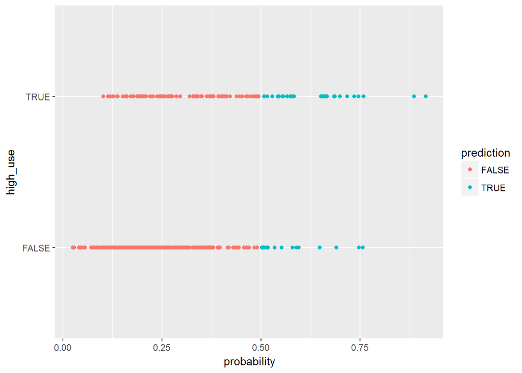

```r
g <- ggplot(alc, aes(x = probability, y = high_use, col=prediction))
g + geom_point()
```

```r
table(high_use = alc$high_use, prediction = alc$prediction)%>%prop.table()%>%addmargins()
```

```
##         prediction
## high_use      FALSE       TRUE        Sum
##    FALSE 0.65183246 0.04973822 0.70157068
##    TRUE  0.22513089 0.07329843 0.29842932
##    Sum   0.87696335 0.12303665 1.00000000
```

From the analyses above we conclude that the model has quite high accuracy (72%), but we should keep in mind that we have not used any additional data.

Next we define a loss function (mean prediction error) as:

```r
loss_func <- function(class, prob) {
  n_wrong <- abs(class - prob) > 0.5
  mean(n_wrong)
}
```

and call it to compute the average number of wrong predictions in the (training) data

```r
loss_func(class = alc$high_use, prob = alc$probability)
```

```
## [1] 0.2748691
```

## Used and useful links

Contingency tables (cross-tabulation), used for preliminary determining dependence of two variables:

https://en.wikipedia.org/wiki/Contingency_table https://www.qualtrics.com/wp-content/uploads/2013/05/Cross-Tabulation-Theory.pdf https://qualityandinnovation.com/2015/02/08/contingency-tables-with-gmodels/

Logit regression: http://www.ats.ucla.edu/stat/r/dae/logit.htm

An Introduction to Statistical Learning with Applications in R, Gareth James, Daniela Witten, Trevor Hastie and Robert Tibshirani, Springer, 2013: http://www-bcf.usc.edu/~gareth/ISL/

Cross-Validation for Predictive Analytics Using R: https://www.r-bloggers.com/cross-validation-for-predictive-analytics-using-r/

## Link to to the GitHub page, related to my work on this course:

https://github.com/noykova/IODS-project